# R Notebook

```r
library(data.table)
library(Rtsne)
library(R.utils)
library(ggplot2)
library(ggcorrplot)
```

# Processing data

## Sade-Feldman(2018) data

```r
fnm1 = "GSE120575_Sade_Feldman_melanoma_single_cells_nolabel_1.txt.gz"
fnm2 = "GSE120575_Sade_Feldman_melanoma_single_cells_2.txt.gz"

sf_tpm1 = fread(paste0("../scRNAseq/Sade_Feldman_2018/", fnm1), fill = TRUE, header = TRUE)

sf_tpm2 = fread(paste0("../scRNAseq/Sade_Feldman_2018/", fnm2), fill = TRUE, drop = 16293, col.names = colnames(sf_tpm1))

ls_tpm = list(sf_tpm1,sf_tpm2)
sf_tpm = rbindlist(ls_tpm)

rm(ls_tpm)
rm(sf_tpm1)
rm(sf_tpm2)
```

```r
dim(sf_tpm) # 55737 x 16292
```

```
[1] 55737 16292
```

```r
gene.names = sf_tpm$V1
rownames(sf_tpm) = gene.names
sf_tpm$V1 = NULL
```

number of cells that each gene is expressed in, to select genes that have expression in a certain amount of cells

```r
gene.grouping = rep(1:28, each = 2000)[1:dim(sf_tpm)[1]]
cells.per.gene = NULL
for (i in 1:28) {
  temp.counts = rowSums(sf_tpm[gene.grouping==i,] > 0)
  cells.per.gene = c(cells.per.gene,temp.counts)
}
large.express.genes.all = gene.names[which(cells.per.gene > 500)] # kept 12705 genes
rm(gene.grouping)
```

## 11 cell types we defined from Sade-Feldman(2018) data

```r
sf_tpm_LEgenes = sf_tpm[large.express.genes.all %in% rownames(sf_tpm), ..clustered_cells]
```

[output not shown]

## percentages of zero expression genes for each cell in each cell type

```r
# calculate the percentages of genes with zero expression for each cell
zeros.per.cell = colSums(clustered_tpm_LEgenes==0) / nrow(clustered_tpm_LEgenes)
zero.percentages = data.frame(percentage.of.zero = zeros.per.cell, grouping = factor(cell_type$type[match(clustered_cells, cell_type$cell)]))
head(zero.percentages)
# distribution of the percentages of zero expression genes for cells by cell type
ggplot(data = zero.percentages) +
  geom_histogram(aes(x=percentage.of.zero), binwidth = 0.01) +
  facet_wrap(~grouping) +
  ggtitle("Distribution of the percentages of zero expression genes")
rm(zeros.per.cell)
```

[output not shown]

```r
fewzero_cells = unname(unlist(by(zero.percentages, zero.percentages$grouping, FUN = function(x) rownames(x)[order(x$percentage.of.zero)][1:100])))
```

## LM22 signature matrix

- select genes that appear both in the LM22 signature matrix and the SF data
- in those genes, further select genes that have expression in a relatively large amount of cells

```r
CBST_LM22 = read.table("../_reference/LM22.txt", sep = "\t", header = TRUE, as.is = TRUE)
head(CBST_LM22)
CBST.SFgenes = CBST_LM22$Gene.symbol[CBST_LM22$Gene.symbol%in%gene.names] # 538 out of 547
CBST.largeExpression.genes = CBST.SFgenes[CBST.SFgenes %in% large.express.genes.all] # 323 out of 538
CBST_SFLEgenes_LM22 = CBST_LM22[CBST_LM22$Gene.symbol%in%CBST.largeExpression.genes,] # 323 x 23
head(CBST_SFLEgenes_LM22)
```

# Compare the correlation of cell types

- Compare the correlation between our 11 cell types.
- Compare the correlation between the cell types in the LM22 vs. the 11 cell types we had.
- Two types of correlation: using all cells for each cell type to calculate mean gene expression, or calculate the mean expression using 100 cells with smallest percentages of zero expression genes.

## Correlations between our 11 cell types

### using mean expression of large expression genes shared between SF data and LM22 matrix

```r
LEgenes_CBST_tpm = as.data.table(t(clustered_tpm_LEgenes[large.express.genes.all %in% CBST.largeExpression.genes,]))
rownames(LEgenes_CBST_tpm) = clustered_cells
colnames(LEgenes_CBST_tpm) = CBST.largeExpression.genes
LEgenes_CBST_tpm[1:5,1:5]
LEgenes_CBST_tpm$grouping = factor(cell_type$type[match(row.names(LEgenes_CBST_tpm), cell_type$cell)])
table(LEgenes_CBST_tpm$grouping)
LEgene_CBST_expression = LEgenes_CBST_tpm[, lapply(.SD, mean), by = grouping] # 11 x 324
LEgene_CBST_expression = LEgene_CBST_expression[order(LEgene_CBST_expression$grouping),]
LEgene_CBST_expression[,1:6]
LEgene_CBST_compare_expression = as.data.frame(t(LEgene_CBST_expression[,-1]))
colnames(LEgene_CBST_compare_expression) = LEgene_CBST_expression$grouping
head(LEgene_CBST_compare_expression)
rm(LEgene_CBST_expression)
rm(LEgenes_CBST_tpm)
```

The patterns of the correlation roughly match our expectation: - Plasma cells, Monocytes/Macrophages, Dendritic cells and B cells do no have major correlation with other cell types, matches the clustering result that these 4 cell types form most distinct clusters - The 3 NK cell clusters are closely related with each other - CD8 cells, NK cells, and CD4 T cells are closely related

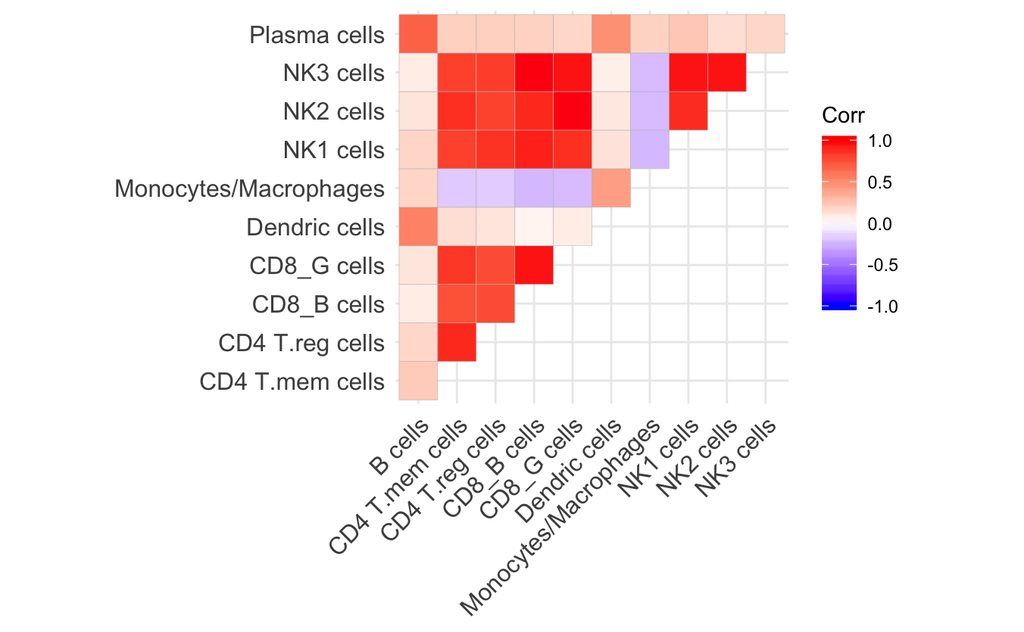

```r
cormat_LE.CBSTgenes_11type = cor(LEgene_CBST_compare_expression, method = "spearman")
ggcorrplot(cormat_LE.CBSTgenes_11type,type = "upper")
```

### using mean expression for large expression genes shared between SF data and LM22 matrix over cells with fewer zero gene expression

```r
LEgene_CBST_few0_expression[,1:6]
```

```
                 grouping  ACAP1   ACP5 ADAM28  ADRB2   AIF1
 1:               B cells 0.1726 2.5379 9.3839 0.0606 0.0427
 2:       CD4 T.mem cells 0.2694 0.6313 1.2052 0.2082 0.2340
 3:       CD4 T.reg cells 3.1859 3.5622 2.5785 0.2111 0.5102
 4:           CD8_B cells 0.7156 5.7225 1.7148 0.1879 0.3756
 5:           CD8_G cells 0.0000 0.5235 0.1751 0.1472 0.4217
 6:         Dendric cells 0.0290 4.6113 0.0831 0.2947 0.1650
 7: Monocytes/Macrophages 2.5100 1.8603 0.2862 0.1251 0.0333
 8:             NK1 cells 1.4674 5.6412 2.3207 0.1509 0.1088
 9:             NK2 cells 0.1774 1.6261 1.0816 0.2185 0.2127
10:             NK3 cells 0.8544 5.8316 2.1186 0.2509 1.2184
11:          Plasma cells 0.0000 6.2608 3.8325 0.0391 0.7229
```

The result using cells with fewer zero expression genes is not very different from the result using all cells.

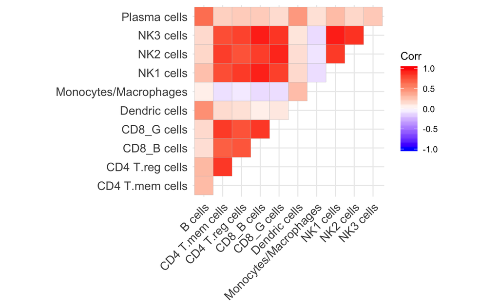

## Correlations between our 11 cell types and the cell types in the LM22 matrix

### using mean expression of large expression genes shared between SF data and LM22 matrix

```r
cormat_LM22_11type = matrix(0,nrow = 22, ncol = 11)
colnames(cormat_LM22_11type)= colnames(LEgene_CBST_compare_expression)
rownames(cormat_LM22_11type) = colnames(CBST_SFLEgenes_LM22)[-1]
for (i in 1:22) {
  for (j in 1:11) {
   cormat_LM22_11type[i,j] = cor(as.numeric(LEgene_CBST_compare_expression[,j]), as.numeric(CBST_SFLEgenes_LM22[,i+1]),method = "spearman")
  }
}
```

The correlations between our 11 cell types and the cell types in the LM22 matrix still have some unexpected patterns

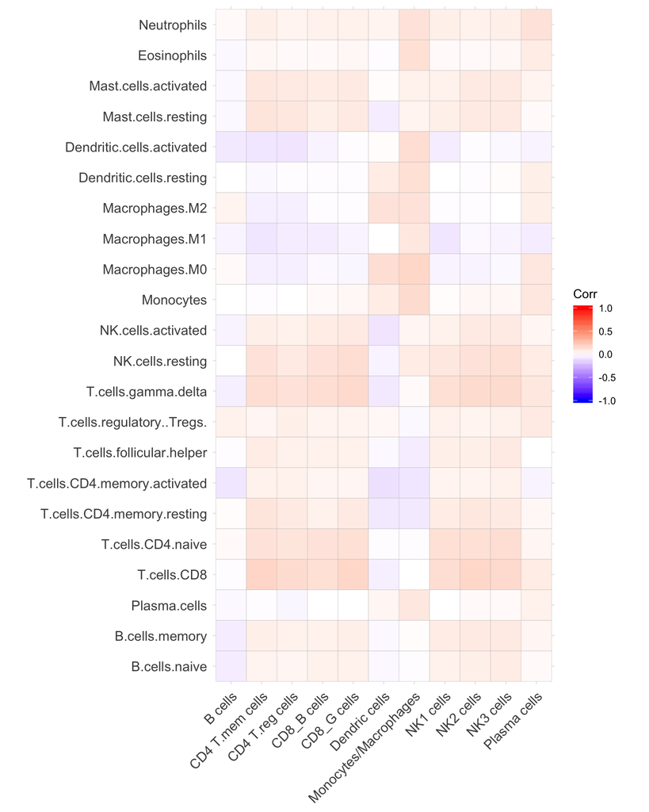

```r
ggcorrplot(t(cormat_LM22_11type))
```

### using mean expression for large expression genes shared between SF data and LM22 matrix over cells with fewer zero gene expression

```r
cormat_LM22_11type_few0 = matrix(0,nrow = 22, ncol = 11)
colnames(cormat_LM22_11type_few0)= colnames(LEgene_CBST_few0_compare_expression)
rownames(cormat_LM22_11type_few0) = colnames(CBST_SFLEgenes_LM22)[-1]
for (i in 1:22) {
  for (j in 1:11) {
   cormat_LM22_11type_few0[i,j] = cor(as.numeric(LEgene_CBST_few0_compare_expression[,j]), as.numeric(CBST_SFLEgenes_LM22[,i+1]),method = "spearman")
  }
}
```

The result using cells with fewer zero expression genes is not very different from the result using all cells.

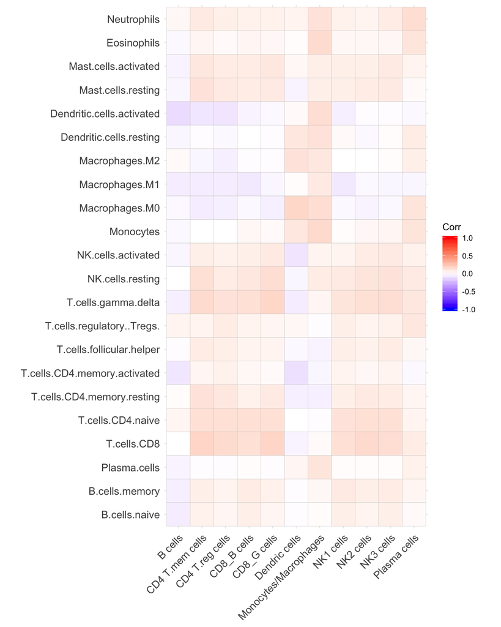

```r
ggcorrplot(t(cormat_LM22_11type_few0))
```